# Confidence intervals for raw residuals

25 February, 2020 Statistics, R

Checking the normality and equal variance of standardized residuals is one of the most common routines when fitting linear models and, although [some statisticians](https://statmodeling.stat.columbia.edu/2013/08/04/19470/) argue they are the less important assumptions to consider [unless you focus on prediction](https://statmodeling.stat.columbia.edu/2013/10/01/ill-say-it-again/), easily available software prompts anyone to either display all kinds of graphical inspections and null hypothesis tests.

Consider fitting the model \(\mathbf{y} = \mathbf{X} \boldsymbol{\beta} + \boldsymbol{\epsilon}\) to \(n\) observations with \(p-1\) predictors. Asumming the error terms follow a multivariate normal distribution with mean vector \(\mathbf{0}\) and covariance matrix \(\sigma^2 \mathbf{I}\), we already know the covariance matrix of the residual vector \(\mathbf{e}\) is \(\sigma^2(\mathbf{I} - \mathbf{H})\), where \(\mathbf{H}\) is the influence matrix. If \(\sigma^2\) was known, confidence intervals could then be constructed because \(\mathbf{e}\) would also follows a multivariate normal distribution. Nonetheless, this situation is utopian because we actually need to estimate the error variance. In this case, we may think that the *ith* studentized residual, \(r_i = \frac{e_i}{\widehat\sigma \sqrt{1 - h_{ii}}}\), follows a t-distribution with \(n-p-1\) degrees of freedom but \(e_i\) and \(\widehat{\sigma}\) are not independent. At this point, we may appeal to asimptotic approximations to simply use the t-distribution or compute the *externally studentized residuals*, which employ the error variance estimate that excludes the *ith* case. If we however want to to use the whole data, Ellenberg (1973) derived the joint distribution of a kind of standardized residuals. We will follow his derivation to get instead the joint density of the internally studentized residuals and will supply `R` code to plot confidence intervals for raw residuals. Because the improvement over the externally studentized residuals may not be huge, this derivation should be taken as a matter of curiosity rather than of practical value.

Let \(\mathbf{M} = \mathbf{I} - \mathbf{H}\) so that \(\mathbf{e} = \mathbf{M} \boldsymbol{\epsilon}\). Consider a \(k\)-subset of residuals. The sum of squared residuals obtained by removing that subset from the regression is
$$S_k^2 = S^2 - \mathbf{e}_k^\top \mathbf{M}_{k\times k}^{-1} \mathbf{e}_k,$$
where \(S^2\) is the sum of squared residuals from the model fitted to the full data, \(\mathbf{e}_k\) is the vector containing the subset of \(k\) residuals and \(\mathbf{M}_{k \times k}\) is the corresponding partition matrix of \(\mathbf{M}\). We can rewrite it as
$$\begin{aligned}
S_k^2 &= \boldsymbol{\epsilon}^\top \mathbf{M} \boldsymbol{\epsilon} - \boldsymbol{\epsilon}^\top (\mathbf{MM^*M}) \boldsymbol{\epsilon} \\
&= \boldsymbol{\epsilon}^\top (\mathbf{M} - \mathbf{MM^*M}) \boldsymbol{\epsilon},
\end{aligned}$$
where \(\mathbf{M^*}\) is a \(n \times n\) matrix with all the entries not related to the \(k\)-subset set to zero. This is a quadratic form where \(\mathbf{M}\) is idempotent and the rank of \((\mathbf{M} - \mathbf{MM^*M})\) is \(n-p-k\), so
$$\frac{S_k^2}{\sigma^2} \sim \chi^2 \Big(n-p-k \Big).$$

$$\begin{aligned}
r_i &= \frac{e_i}{\widehat{\sigma} \sqrt{m_{ii}}} \\
\widehat{\sigma}^2 &= \frac{S_i^2 + \widehat{\sigma}^2 r_i^2}{(n-p)}
\end{aligned},$$

Notice that by standardazing the residuals we ensure that \(\sigma^2 = 1\). The joint probability density now looks like
$$f(e_i, S_i^2) = \mathcal{N} \Big(r_i \widehat{\sigma} \sqrt{m_{ii}}; \ 0, m_{ii} \Big) \ \chi^2 \left(\widehat{\sigma}^2 (n-p-r_i^2); \ n-p-1 \right).$$

Denoting \(v = n-p\), the Jacobian of the transformation is
$$\begin{equation}
\begin{vmatrix}
\widehat{\sigma} \sqrt{m_{ii}} & r_i \sqrt{m_{ii}} \\
-2 \widehat{\sigma}^2r_i & 2 \widehat{\sigma}v - 2\widehat{\sigma} ri^2
\end{vmatrix} = 2\widehat{\sigma}^2v \sqrt{m_{ii}}
\end{equation}.$$

Hence,
$$f(r_i, \widehat{\sigma}) = 2\widehat{\sigma}^2v \sqrt{m_{ii}} \ \mathcal{N} \Big(r_i \widehat{\sigma} \sqrt{m_{ii}}; \ 0, m_{ii} \Big) \ \chi^2 \Big(\widehat{\sigma}^2 (v-r_i^2); \ v-1 \Big).$$

Finally, simplifying and integrating over \(\widehat{\sigma}\) yields
$$f(r_i) = \frac{v^{1-v/2} (v-r_i^2)^{(v-3)/2} \Gamma \left(\frac{v}{2} \right)}{\Gamma \left(\frac{v-1}{2} \right) \sqrt{\pi}}, \quad \mid r_i \mid < \sqrt{v}.$$

Using \(\tt Mathematica\) we find
$$F(r_i) = \frac{v^{1-\frac{v}{2}} \Gamma \left(\frac{v}{2} \right)}{\Gamma \left(\frac{v-1}{2} \right) \sqrt{\pi}} r_i \left(1 - \frac{r_i^2}{v} \right)^{\frac{3-v}{2}} \Big(v-r_i^2 \Big)^{\frac{v-3}{2}} \\
_2F_1 \left( \frac{1}{2}, \frac{3-v}{2}, \frac{3}{2}, \frac{r^2}{v} \right) + C,$$
where \(_2F_1\) is the hypergeometric function. A visual inspection of \(F(x)\) indicates that \(C = \frac{1}{2}\) and the calculation of p-values and confidence intervals is straightforward. We just need to find the \(1-\alpha/2\) percentile, multiplicate it by \(\widehat{\sigma}\sqrt{m_{ii}}\) and add \(e_i\).

The `R` function `resid_ci` takes the output of a `lm` class object and does all the work.

```r
# Distribution function of r:
pr <- function(r, v) {
  if(abs(r) >= sqrt(v)) {
    return(0)
  }
  v^(1-v/2)*gamma(v/2)/(gamma((v-1)/2) * sqrt(pi))*
  r*(1-r^2/v)^((3-v)/2)*(v-r^2)^((v-3)/2)*
    Re(hypergeo::hypergeo(1/2, (3-v)/2, 3/2, r^2/v)) + 1/2
}
# Notice you need the 'hypergeo' package.

# Function to get and plot the confidence intervals:
resid_ci <- function(lm, confidence, plot = NULL) {
   alpha <- 1 - confidence
   hat_y <- modelo$fitted.values
   e <- modelo$residuals
   v <- modelo$df.residual
   hat_sigma2 <- sum(e^2) / v
   m <- 1 - lm.influence(modelo)$hat
   se <- sqrt(hat_sigma2 * m)
   r <- e / se
   # Bounds for the domain of r:
   u <- sqrt(v) - 0.01
   l <- -u
   critical_value <- uniroot(f = function(r, v, alpha) pr(r, v) - (1-alpha/2),
          v = v, alpha = alpha, lower = l, upper = u)$root
   CI <- sapply(c(-1, 1), FUN = function(x) e + x*critical_value * se)
   colnames(CI) <- c("lower limit", "upper limit")
   if(!is.null(plot)) {
      plot(hat_y[plot], e[plot], ylim = c(max(CI[plot, ]), min(CI[plot, ])),
        ylab = "Residuals", xlab = "Fitted values")
      sapply(plot, FUN = function(x) segments(x0 = hat_y[x], x1 = hat_y[x],
                                          y0 = CI[x, 1], y1 = CI[x, 2]))
      segments(x0 = min(hat_y[plot]), x1 = max(hat_y[plot]), y0 = 0, y1 = 0, lty = 2)
   }
   return(CI)
}
```

The `plot` argument can be used to plot a subset of residuals by providing its indexes.

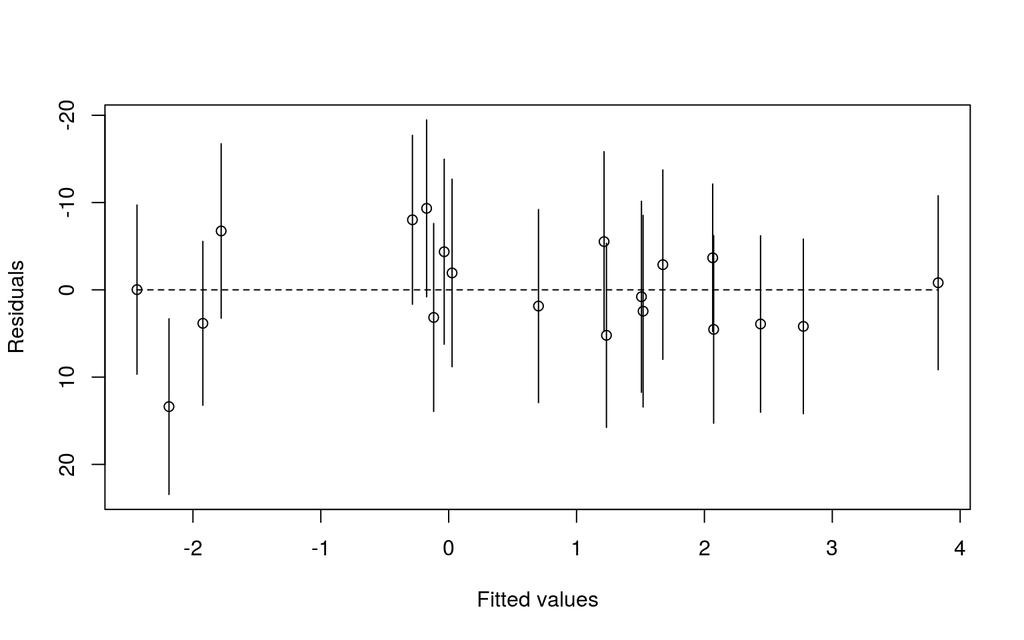

```
##    lower limit upper limit
## 1   -19.464750   0.7951401
## 2   -17.696498   1.6501012
## 3    -5.550288  13.2235236
## 4   -15.831542   4.7842290
## 5    -6.212853  15.2809272
## 6   -10.152657  11.7342894
## 7   -14.961725   6.2331182
## 8    -5.813860  14.1868663
## 9   -16.738508   3.2498009
## 10  -13.733734   7.9669237
## 11   -8.529167  13.4177885
## 12  -10.779609   9.1548674
## 13  -12.121683   4.7811506
## 14   -6.199955  14.0267908
## 15    3.315743  23.4428353
## 16   -5.336643  15.7564900
## 17  -12.674718   8.8032118
## 18   -9.720376   9.6704875
## 19   -9.200522  12.9166644
## 20   -7.601659  13.9297983
```

```r
set.seed(25022020)
# Set-up:
n <- 20
p <- 4
v <- n-p
X <- cbind(1, MASS::mvrnorm(n, mu = rep(0, p-1), Sigma = diag(p-1)))
beta <- c(1, 0.2, 0.5, 0.8)
sigma <- rchisq(1, 5)
# Simulation:
epsilon <- rnorm(n, 0, sigma)
y <- X %*% beta + epsilon
# Model:
modelo <- lm(y ~ 0 + X)
# Plotting the confidence intervals with alpha = .05:
resid_ci(modelo, confidence = .95, plot = 1:n)
```

And as we should expect in the long run under the homocedastic and normality assumptions, only one of the \(20\) residuals deviated from the model.

# Reference

Ellenberg, J. H. (1973). The Joint Distribution of the Standardized Least Squares Residuals from a General Linear Regression. *Journal of the American Statistical Association*, *68*(344), 941–943. https://doi.org/10.1080/01621459.1973.10481450